# SoccerGraph

Jesús Lagos @Vdot_spain

2019-06-28

La libreria socccergraph está pensada para todos aquellos que trabajen con los datos de OPTA y para que las personas que estén estudiando o quieran conocer los datos puedan analizarlos y hacer visualizaciones y análisis de los mismos. Con esta libreria podrás:

- Parsear los xml de Opta (Hay 6 ficheros de ejemplo pero solo están desarrollados los parseadores para pass_matrix y f24)
- Analizar los grafos de pases y gráficas de radar
- Análizar las zonas de tiro
- Mapas de calor de pases
- Amálisis de corners

## OPTAXMLEVENTOS

Con esta función `df<-OptaXMLeventos(ruta_fichero)` podrás pasar el xml f24 a un dataframe teniendo cada evento por linea y sus cualificadores por columna

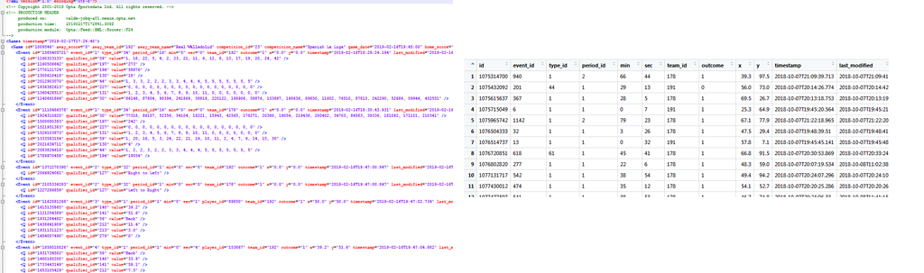

A la izq XML de Opta, a la derecha convertido a dataframe

## OPTAXMLPASSMATRIX

Con esta función `df<-OptaXMLpassmatrix(ruta_fichero)`podrás pasar el xml Pass_matrix a un dataframe teniendo cada jugador repetido por cada conexión con otro jugador

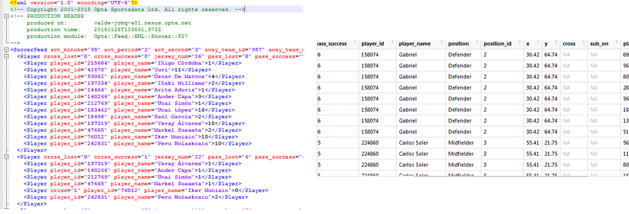

A la izq XML de Opta, a la derecha convertido a dataframe

## OPTAMAPMATRIXMAP

Con esta función `OptaMAPmatrixpass(df,4)` se lee el data frame parseado y se genera un grafo que conecta cada jugador con los otros jugadores según los pases realizados en el partido. El segundo parámetro indica el número de pases mínimo a tener en cuenta (si no queremos representar si un jugador pasa 1 vez a otro por ejemplo)

Además cada jugador será representado en la coordenada del XML, con un tamaño de punto según el número de pases exitosos y en color más claro si tiene más centralidad en el grafo.

Las lineas se representan en de Rojo a Azul en función del número de pases. Cuanto más rojo más pases se han dado entre esos jugadores.

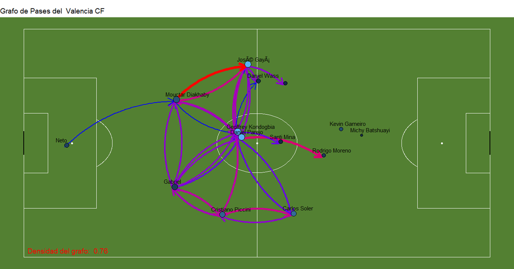

También puedes usar la función `grid.arrange(p1, p2,p4,p5,p6,p7,p8, nrow = 2)` si por ejemplo tienes 8 ficheros (no los hay en el paquete) y representar varios partidos a la vez:

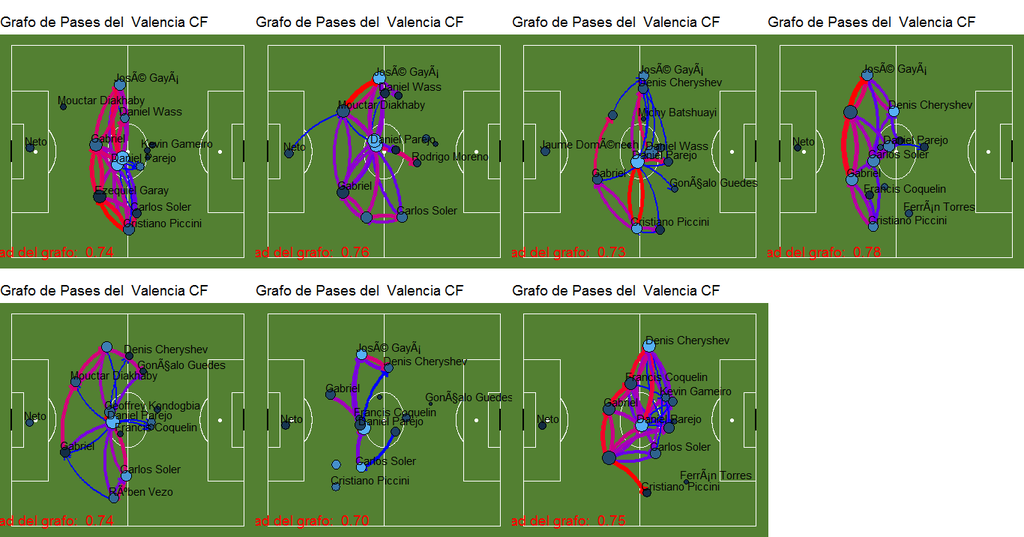

## OPTAMAPCORNER

Con esta función `OptaMAPcorner(df,1)` podrás visualizar en un mapa de calor las zonas donde saca los corners un equipo y el tipo de remate y con que parte del cuerpo fue realizado.

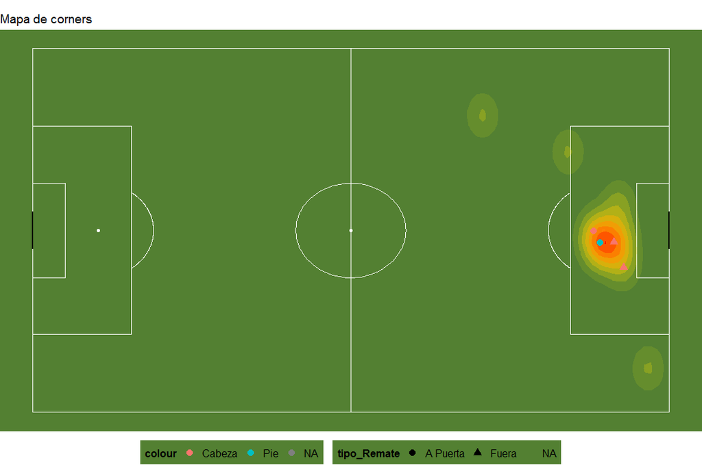

## OPTAMAPDIRECTPASS

Con esta función `OptaMAPdirectpass(df,1)` podrás visualizar en un mapa a cada jugador con su gráfico de radar ubicado en la coordenada promedio de sus pases.

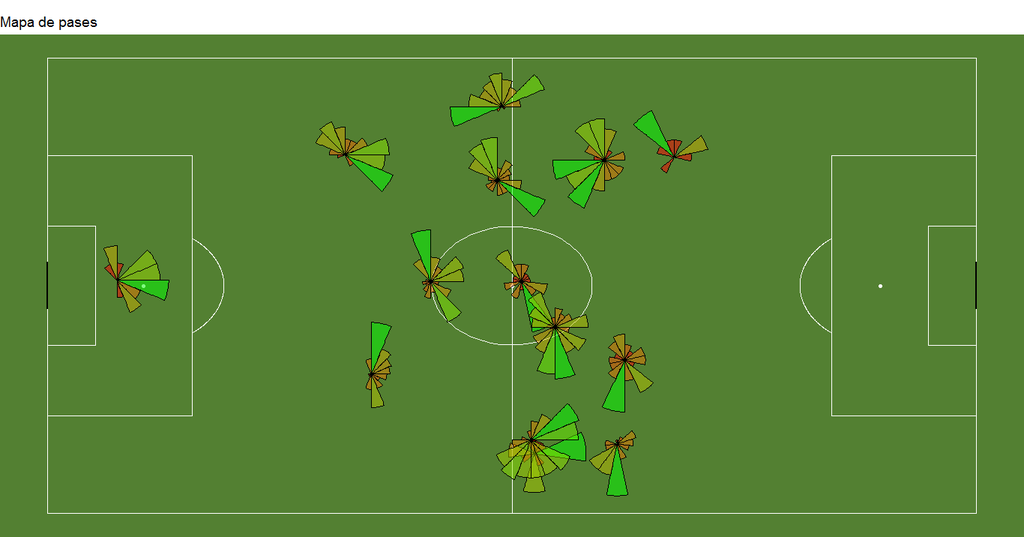

También puedes usar la función `grid.arrange(p1, p2,p4,p5,p6,p7,p8, nrow = 2)` si por ejemplo tienes 8 ficheros (no los hay en el paquete) y representar varios partidos a la vez:

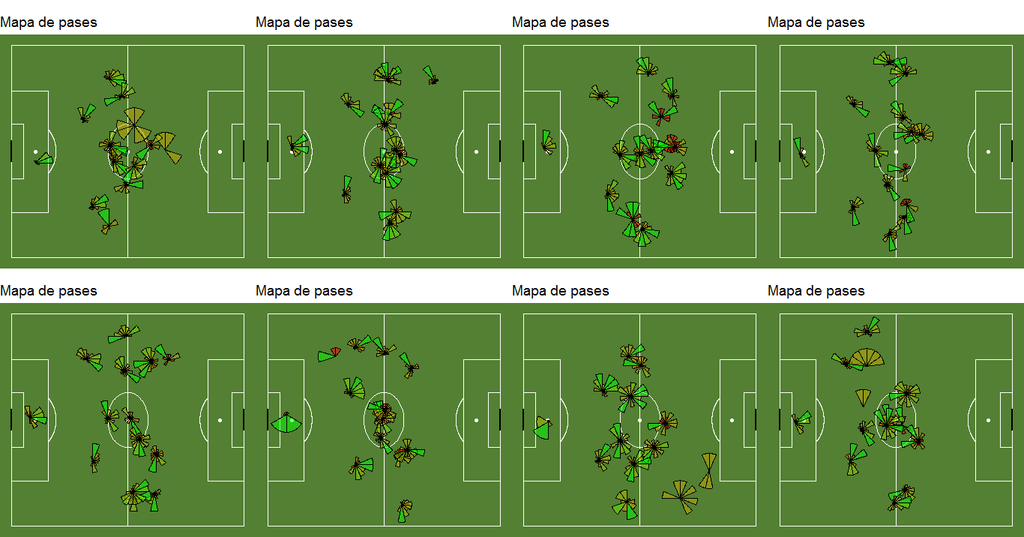

## OPTAMAPHEATMAPFROM AND OPTAMAPHEATMAPFROM

Con estas funciones `OptaMAPheatMapFrom(df,1)` y `OptaMAPheatMapTo(df,1)` podrás visualizar un mapa por jugador con su mapa de calor desde donde pasan y adonde pasan

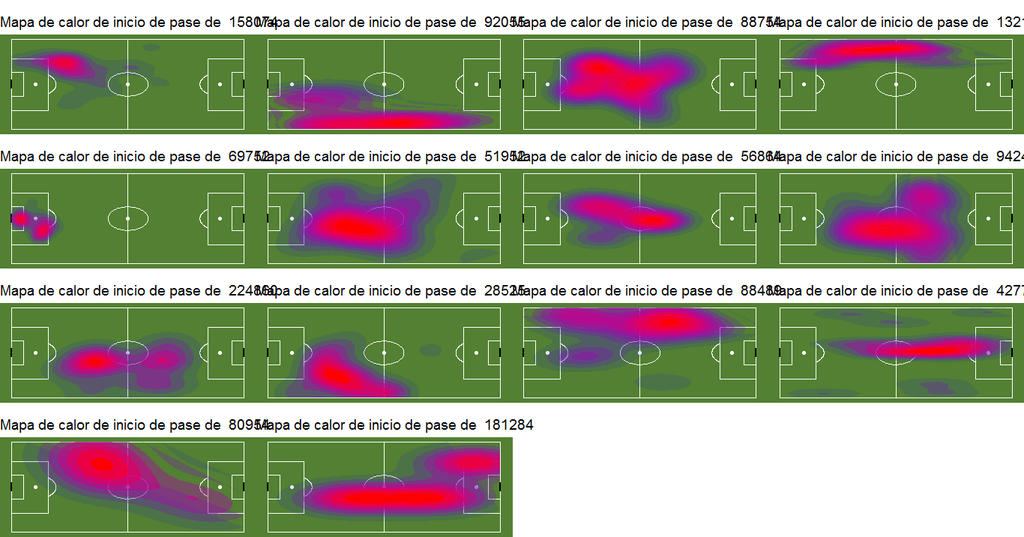

Zonas desde donde pasan los jugadores

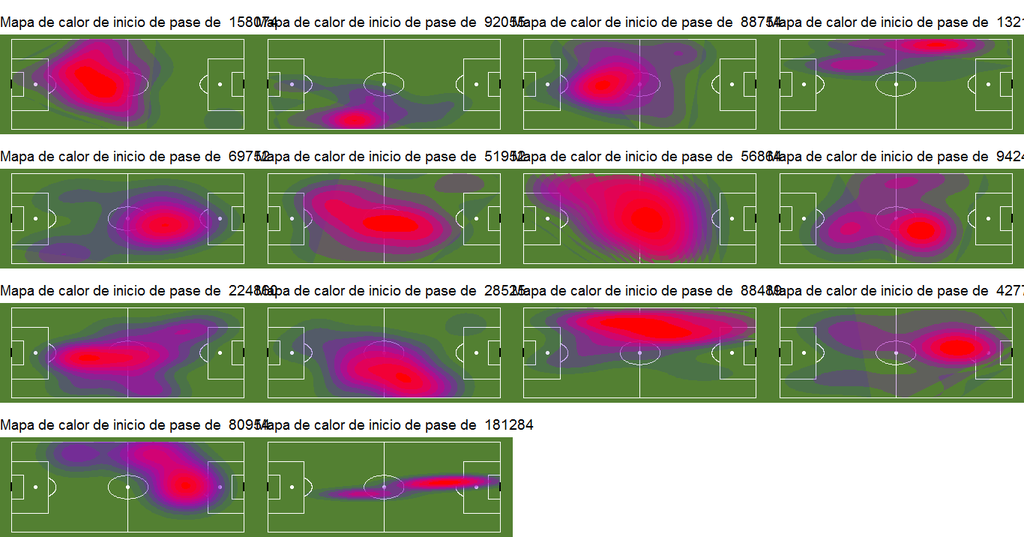

Zonas adonde pasan los jugadores

## OPTAMAPSHOOT

Con esta función `OptaMAPshoot(df,1))` podrás visualizar una porteria y adonde se ha dirigido cada tiro, cual fue gol y según el tamaño la distancia de donde fue realizado.

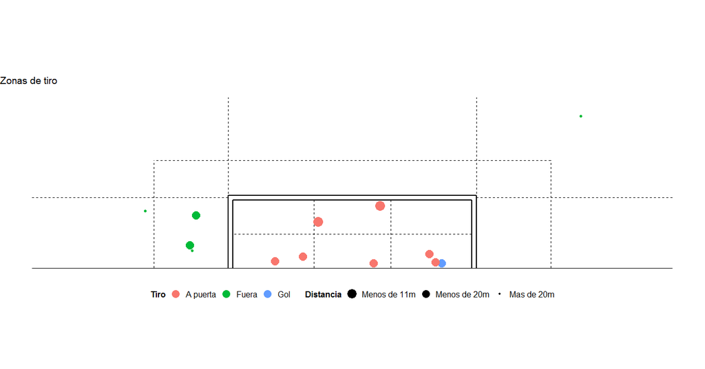

## FUTURAS MEJORAS

- INCLUIR UN MAPA CON EL MODELO XG (GOLES ESPERADOS)
- ANALIZAR EL RESTO DE FICHEROS